# Sid’s Data Science Portfolio

- Show All Code
- Hide All Code
- View Source

Exploring Data Through Analytics and Visualization

Author

Sid Jena

Published

October 16, 2025

# Welcome to My Data Science Portfolio

Welcome to my portfolio showcasing data science projects, statistical analyses, and data visualizations. This site demonstrates my skills in Python, data manipulation, statistical modeling, and creating compelling visualizations.

## About Me

I’m passionate about turning data into insights and creating meaningful visualizations that tell stories. This portfolio contains various projects spanning different domains of data science and analytics.

## Featured Analysis: Stock Market Trends

Let me demonstrate with a sample analysis of simulated stock market data:

```python
import matplotlib.pyplot as plt
import numpy as np
import pandas as pd
from datetime import datetime, timedelta

# Set random seed for reproducibility
np.random.seed(42)

# Generate sample data
dates = pd.date_range(start='2023-01-01', end='2023-12-31', freq='D')
n_days = len(dates)

# Simulate stock prices with trend and volatility
base_price = 100
trend = np.linspace(0, 20, n_days)  # Upward trend
volatility = np.random.normal(0, 2, n_days)  # Random fluctuations
prices = base_price + trend + volatility

# Create DataFrame
stock_data = pd.DataFrame({
    'Date': dates,
    'Price': prices,
    'Volume': np.random.randint(1000000, 5000000, n_days)
})

# Calculate moving averages
stock_data['MA_20'] = stock_data['Price'].rolling(window=20).mean()
stock_data['MA_50'] = stock_data['Price'].rolling(window=50).mean()

print(f"Data shape: {stock_data.shape}")
print(f"Price range: ${stock_data['Price'].min():.2f} - ${stock_data['Price'].max():.2f}")
```

```
Data shape: (365, 5)
Price range: $96.89 - $122.90
```

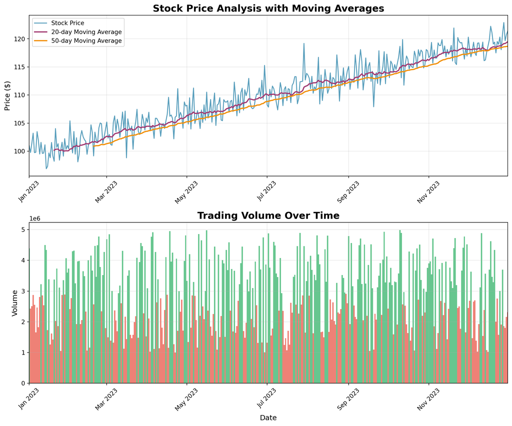

```python
# Create the main visualization
fig, (ax1, ax2) = plt.subplots(2, 1, figsize=(12, 10))

# Plot 1: Stock Price with Moving Averages
ax1.plot(stock_data['Date'], stock_data['Price'],
         linewidth=1.5, alpha=0.8, label='Stock Price', color='#2E86AB')
ax1.plot(stock_data['Date'], stock_data['MA_20'],
         linewidth=2, label='20-day Moving Average', color='#A23B72')
ax1.plot(stock_data['Date'], stock_data['MA_50'],
         linewidth=2, label='50-day Moving Average', color='#F18F01')

ax1.set_title('Stock Price Analysis with Moving Averages', fontsize=16, fontweight='bold')
ax1.set_ylabel('Price ($)', fontsize=12)
ax1.legend(loc='upper left')
ax1.grid(True, alpha=0.3)
ax1.set_xlim(stock_data['Date'].min(), stock_data['Date'].max())

# Plot 2: Trading Volume
colors = ['#E74C3C' if x < stock_data['Volume'].mean() else '#27AE60'
          for x in stock_data['Volume']]
ax2.bar(stock_data['Date'], stock_data['Volume'],
        color=colors, alpha=0.7, width=1)

ax2.set_title('Trading Volume Over Time', fontsize=16, fontweight='bold')
ax2.set_xlabel('Date', fontsize=12)
ax2.set_ylabel('Volume', fontsize=12)
ax2.grid(True, alpha=0.3)
ax2.set_xlim(stock_data['Date'].min(), stock_data['Date'].max())

# Format x-axis dates
import matplotlib.dates as mdates
for ax in [ax1, ax2]:
    ax.xaxis.set_major_locator(mdates.MonthLocator(interval=2))
    ax.xaxis.set_major_formatter(mdates.DateFormatter('%b %Y'))
    ax.tick_params(axis='x', rotation=45)

plt.tight_layout()
plt.show()
```

## Key Insights

```python
# Calculate some basic statistics
price_stats = {
    'Starting Price': f"${stock_data['Price'].iloc[0]:.2f}",
    'Ending Price': f"${stock_data['Price'].iloc[-1]:.2f}",
    'Total Return': f"{(stock_data['Price'].iloc[-1] / stock_data['Price'].iloc[0] - 1) * 100:.1f}%",
    'Average Daily Volume': f"{stock_data['Volume'].mean():,.0f}",
    'Price Volatility (Std Dev)': f"${stock_data['Price'].std():.2f}"
}

print("📊 Stock Performance Summary:")
print("=" * 40)
for key, value in price_stats.items():
    print(f"{key:<25}: {value}")
```

```
📊 Stock Performance Summary:
========================================
Starting Price           : $100.99
Ending Price             : $121.38
Total Return             : 20.2%
Average Daily Volume     : 2,917,192
Price Volatility (Std Dev): $6.21
```

## Portfolio Projects

### 📈 Financial Analysis

- Stock market trend analysis
- Portfolio optimization models
- Risk assessment frameworks

### 🏥 Healthcare Analytics

- Patient outcome predictions
- Medical data visualization
- Clinical trial analysis

### 🛒 Business Intelligence

- Customer segmentation
- Sales forecasting
- Market research insights

### 🌍 Social Impact

- Climate data analysis
- Economic inequality studies
- Public policy evaluation

## Technical Skills

- **Programming**: Python, R, SQL
- **Data Analysis**: Pandas, NumPy, SciPy
- **Visualization**: Matplotlib, Seaborn, Plotly
- **Machine Learning**: Scikit-learn, TensorFlow
- **Statistical Modeling**: Regression, Time Series, Bayesian Methods
- **Tools**: Jupyter, Git, Docker, AWS

## Get in Touch

I’m always interested in discussing data science projects, collaboration opportunities, or new challenges. Feel free to reach out through the contact information provided in my profile.

*This portfolio is built with [Quarto](https://quarto.org/) - a powerful tool for creating dynamic documents and websites.*